# Larval zebrafish Trust STK_50 min

Dr. Sheifer

Cognitive Disorders Research Lab

26 October, 2026

# Introduction

## Background

The Pamstation12 instrument provides a profiling of kinase activity of cell or tissue samples. The device is loaded with either serine/threonine or tyrosine microarray chips. Each chip has 4 wells, so four samples can be loaded on a single chip, and the Pamstation12 can accommodate 3 chips per run. The microarray represents 144 (STK chip) or 196 (PTK chip) reporter peptides that can be phosphorylated by serine/threonine or tyrosine kinases. The device measures the degree of the phosphorylation in real time by detecting fluorescent labeled antibodies at different exposure times. The list of peptides present in each microarray can be viewed here: [STK chip](https://pamgene.com/wp-content/uploads/2020/09/STK-144-PamChip-87102.pdf), [PTK chip](https://pamgene.com/wp-content/uploads/2020/09/PTK-196-PamChip-86402.pdf)

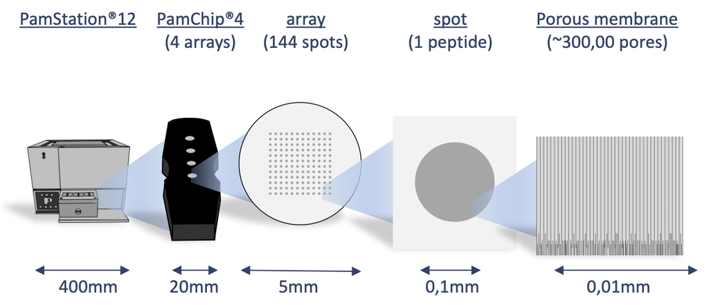

PamGene Kinase Activity Platform

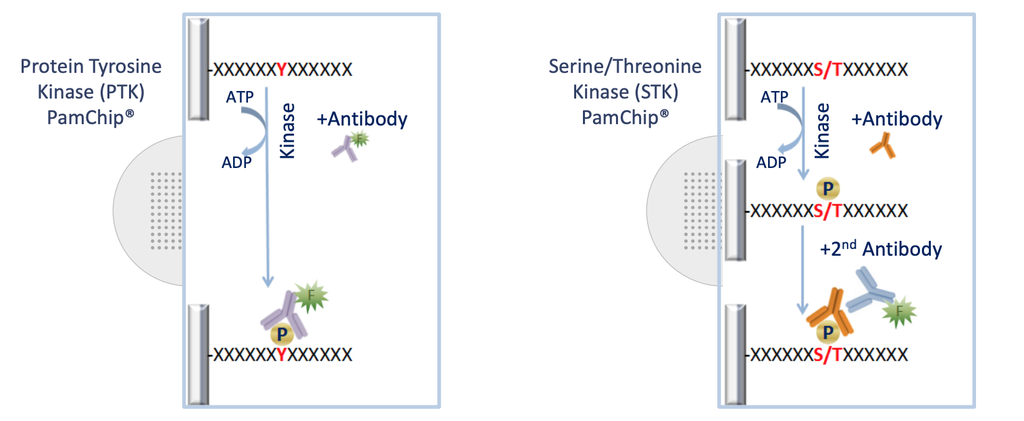

PamGene Platform Detection

# Run Design

Designing the placement of the samples on the chips and arrays is important to consider due to the variability across different chips and batches. During the run some wells are subject to fail and their data cannot be analyzed and shown below as red.

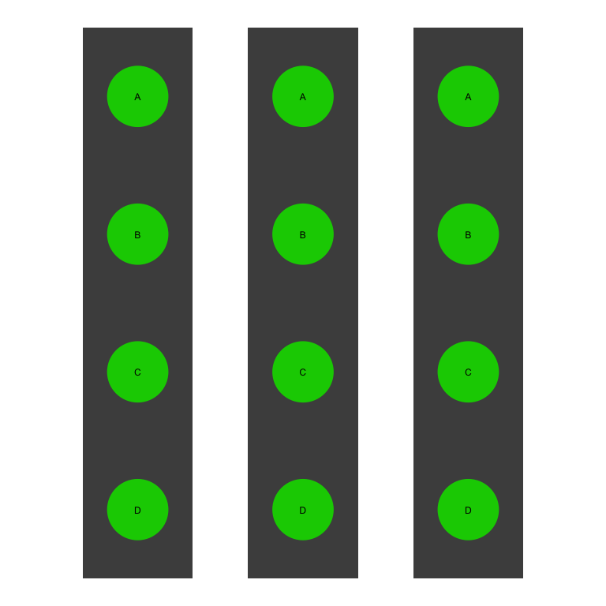

# Results

## Image Analysis

The first step of analyzing the run is to convert the images taken by the PamStation of each array at different exposure times to numerical values. This is done by the Bionavigator software developed by PamGene. The software recognizes the grid of the array with the aid of the searching algorithm (Pamgrid) to correctly identify each spot on the array. The numbers produced by this software represent the median value of the foreground pixels minus the median value of the background pixels to produce the median signal minus background (Median_SigmBg).

## Reading Data

The first step will be reading the crosstab view bionavigator files (Median_SigmBg and Signal_Saturation) and defining the PamChip type (STK or PTK). The raw data is read and then transformed to be in tidy format for an easier analysis, modeling, and visualizing.

## QC Initial Steps and Groups Assignments

We will perform a couple of quality control steps to deal with negative values in the data and adjust based on signal saturation (optional). Next, we will define a new column to represent the grouping. And then, we will extract end point signal values

# Objective

This analysis evaluates whether inclusion of the 100-ms exposure affects raw signal behavior, exposure-response linearity, and peptide retention through the standard KRSA quality-control pipeline. A corrected branch excluding 100 ms is compared with the original branch that includes exposures through 100 ms.

```
#> # A tibble: 4 × 2
#>   Group                n_samples
#>   <chr>                    <int>
#> 1 5-MeO-DMT_50min              1
#> 2 PAL_50min                    1
#> 3 Photo-5MeO-DMT_50min         1
#> 4 Veh_50min                    1
#>                  chip_type               report_cycle           signal_threshold corrected_signal_threshold        linearity_threshold
#>                          1                          1                          1                          1                          1
```

# Dataset overview

| Dataset characteristic | Value |
| --- | --- |
| Chip type | STK |
| Samples | 4 |
| Barcodes | 1 |
| Analytical peptides | 141 |
| Available exposure times (ms) | 1, 5, 10, 25, 50, 100 |
| Cycle used for exposure plots | 124 |
| 100-ms signal threshold | 5 |
| 50-ms signal threshold | 3 |
| Linearity threshold | 0.8 |

# Custom cycle-level quality control

Because the 100-ms images are suspected to be overexposed, the preliminary high-signal screen uses exposures through 50 ms. This screen selects measurable peptides for cycle-level anomaly detection; it is not the final KRSA peptide filter.

For each sample, barcode, peptide, and cycle, the model $Signal = slope \times ExposureTime$ is fitted through the origin. Consecutive cycles are compared using the change in transformed slope. A transition fails when its absolute delta exceeds 2.5, or when its peptide-specific absolute z-score exceeds 3 and either adjacent model has $R^2 < 0.8$.

| Cycle-level QC metric | Result |
| --- | --- |
| Evaluated cycle transitions | 2576 |
| Failed transitions | 56 |
| Failed peptide-cycle combinations | 56 |
| Measurement rows removed | 231 |
| Measurement rows retained | 19065 |

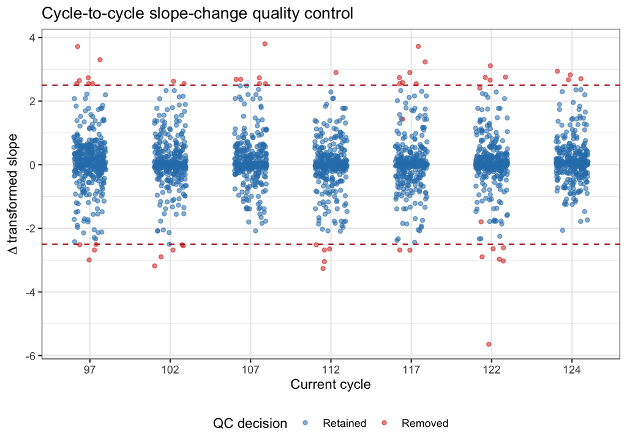

The failed peptide-cycle combinations were removed before creating either exposure-time branch, ensuring that both branches start from the same cleaned dataset.

# Exposure-time behavior at the final cycle

The following plots use unmodeled signal values from cycle 124 and exclude reference/control peptides. Conditions and replicates are taken from the data; no study-specific group names are hard-coded.

## Median raw signal versus exposure time

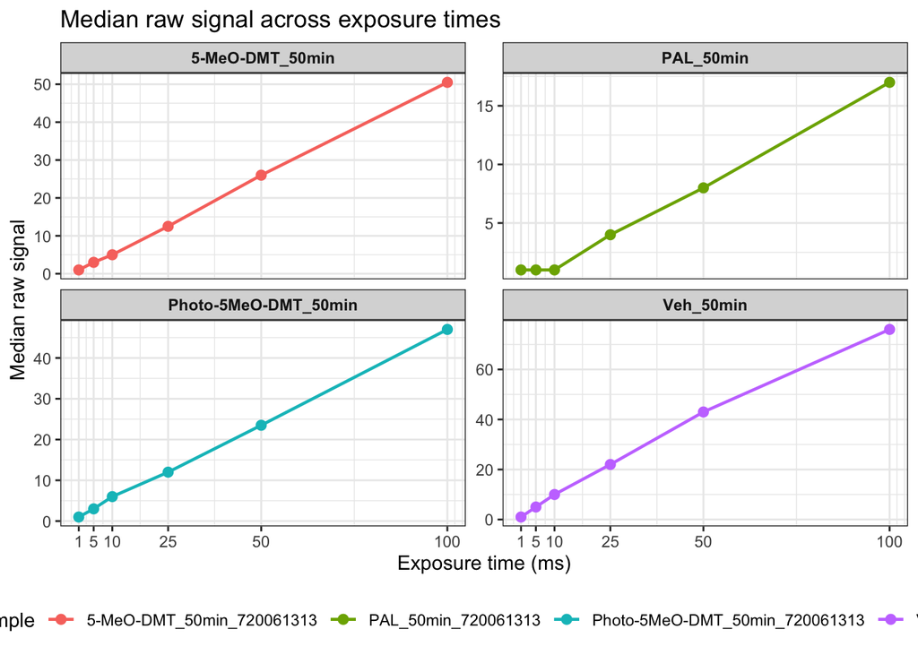

This plot shows whether median signal increases consistently with exposure time or declines at the 100-ms exposure within individual samples.

## Number of measurable peptides versus exposure time

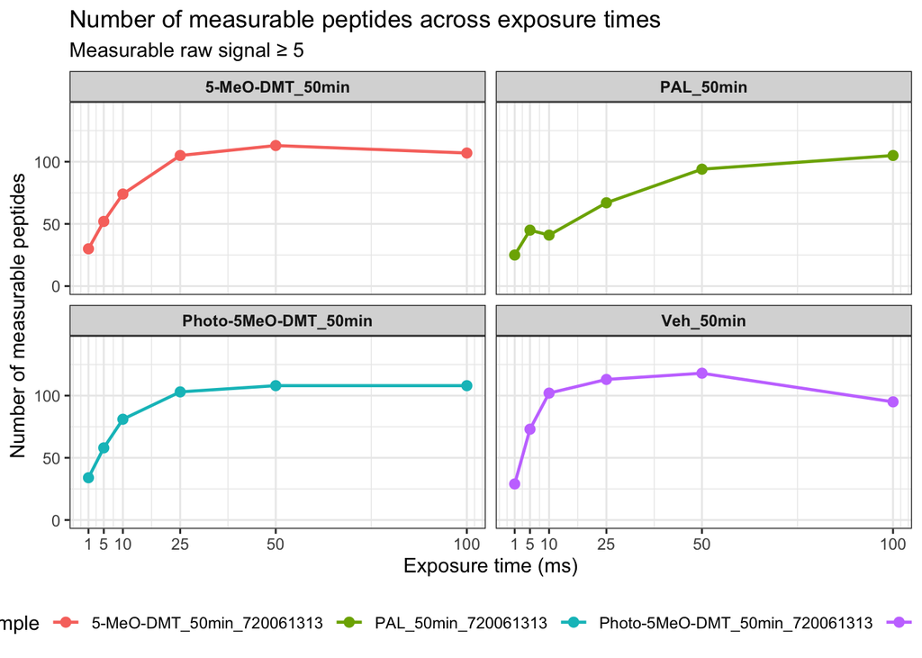

This plot evaluates whether longer exposure improves peptide detection or causes the number of measurable peptides to fall at 100 ms.